# 시험의 종말

AI가 깨뜨린 것은 문제가 아니라 ’혼자서’라는 조건이다 — 계량심리학 × 신호경제학 × 보안공학

저자

Insight Lab × Claude

공개

2026년 11월 18일

**노트핵심 문장**

시험은 처음부터 지식을 재는 장치가 아니었다. **“정해진 시간에, 혼자서”라는 조건을 강제한 다음 그 조건 아래서 나온 결과를 재는 장치**였다. 생성형 AI는 문제를 어렵게 만들지 않았다. 그 조건을 지키는 비용을 폭증시켰다. 그래서 끝나는 것은 시험 전체가 아니라 **싸게 대량으로 치르는 시험**이다. 조건을 지킬 수 있는 시험(대면·구술·과정 기록)은 오히려 더 비싸지고 더 중요해진다. 시험의 종말과 시험의 귀환은 같은 현상의 양면이다.

# 1 수능 전날, 세무사 수석이 자백했다

2027학년도 수능은 2026년 11월 19일이다. 그 직전 주에 제63회 세무사 시험 **수석 합격자**가 생성형 AI로 부정행위를 했다고 자수했다. 보도에 따르면 초소형 카메라로 문제를 찍어 AI로 보내고, 답은 스마트폰으로 받았다. 같은 수법을 공인회계사 1차 시험에도 썼지만 그 시험에서는 떨어졌다. 고사실에는 감독관이 2명 있었지만 휴대전화를 걷지 않았고 CCTV는 없었다. 정부는 최근 3~5년치 세무사 시험을 다시 점검하겠다고 밝혔고, 한국산업인력공단은 안경 전수 확인, 전파탐지기 도입, CCTV 확대, 제보센터 신설을 검토하고 있다.

이 사건 하나만 있었던 게 아니다. 비슷한 일이 1년 넘게 이어졌다.

- **2025년 11월**: 연세대의 600명 규모 비대면 강의 중간고사에서 집단 AI 커닝 의혹이 나왔고, 40여 명이 자수했다. 고려대와 서울대에서도 비슷한 의혹이 이어졌다.
- **2026년 5월**: 전기산업기사·소방설비기사 시험에서 AI 글라스를 쓴 응시자 3명이 적발됐다. 이후 토익 정기시험에서도 2명이 적발됐다.
- **2026년 10월**: 서울시립대(10/3)와 연세대(10/10) 수시 논술시험에서 스마트안경이 적발됐다. 둘 다 감독관이 안경을 확인한 뒤 시험이 시작되자 바꿔 쓴 경우였다. 교육부는 10월 13일 전체 대학에 감독 강화 공문을 보냈고, 15일에는 수능 감독관용 대응 매뉴얼을 보냈다.

처음에 사람들은 비대면 시험만의 문제라고 생각했다. 그래서 대면 시험으로 돌아가자는 말이 나왔다. 그러나 2026년의 사례는 **대면 시험장 안에서** 일어났다. 무게 50g 안팎의 음성형 AI 글라스는 이제 일반 뿔테 안경과 눈으로 구별하기 어렵다.

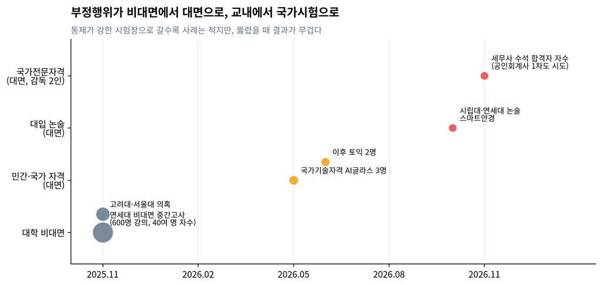

그림 1: 한국에서 보도된 AI 부정행위 사건의 흐름(2025.11~2026.11). 가로축은 시점이고, 세로 위치는 시험 환경이다(위로 갈수록 통제가 강하다). 점 크기는 보도된 관련 인원의 대략적 규모이며, 정확한 적발 통계가 아니다. 출처: 경향신문·서울신문(2025.11), 연합뉴스(2026.8.2), 서울신문(2026.10.14), MTN(2026.11.15~16) 보도.

# 2 숫자로 본 붕괴

한국에는 아직 AI 부정행위 공식 통계가 없다. 비교적 체계적인 데이터는 영국에 있다. 가디언은 2025년 영국 대학 131곳에 정보공개청구를 했다. 그 결과 2023-24학년도에 **AI 부정행위로 확정된 사례가 약 7,000건, 학생 1,000명당 5.1건**이었다. 2022-23학년도의 1.6건에서 세 배로 늘었다. 2024-25학년도는 학년 중간 집계로 1,000명당 7.5건이 예상됐다. 같은 기간 전통적 표절은 1,000명당 19건에서 15.2건으로 줄었다. 부정행위가 없어진 게 아니다. 수단이 바뀌었다.

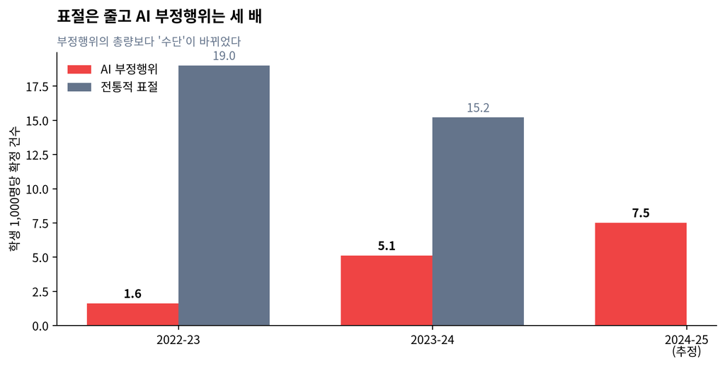

그림 2: 영국 대학의 학생 1,000명당 확정된 부정행위 건수. 2024-25는 5월까지 집계한 값으로 추정한 연간치다. 응답 기관의 27% 이상은 AI 부정행위를 별도로 분류하지 않았으므로 실제보다 적게 잡혔을 가능성이 크다. 출처: The Guardian 정보공개청구 조사(2025.6), eWeek 재인용.

사용률을 보면 더 분명하다. 영국 고등교육정책연구소(HEPI)는 해마다 학부생에게 생성형 AI 사용 여부를 묻는다. **평가 과제에 생성형 AI를 전혀 쓰지 않는다**는 학생은 2024년 47%였다. 2025년에는 11%, 2025년 12월에 조사한 2026년 보고서에서는 **6%**로 줄었다. 2년 만에 소수와 다수가 자리를 바꿨다. 쓰는 방식의 대부분은 개념 설명, 요약, 구조 잡기다. 부정행위와 같다고 볼 수 없다. 그러나 평가하는 쪽에서 보면 결과물만으로는 둘을 구별할 수 없다.

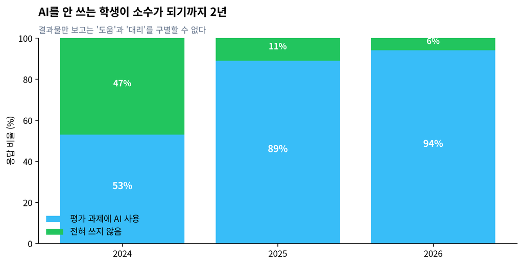

그림 3: 영국 학부생 중 평가 과제에 생성형 AI를 ’전혀 쓰지 않는다’고 답한 비율. 2026년 조사는 2025년 12월에 실시했다(n=1,054). AI 사용은 부정행위와 같지 않다. 대부분의 사용은 개념 설명·요약·구조화다. 출처: HEPI/Kortext Student Generative AI Survey 2024·2025·2026(HEPI Report 199).

# 3 시험이 원래 재던 것: 계량심리학의 시각

계량심리학에서 시험 점수는 능력 그 자체가 아니다. **관찰된 점수 = 능력 + 오차**라는 모형에서 출발한다. 메시크(Messick)가 정리한 타당도 개념에 따르면, 점수가 의미를 가지려면 측정 조건이 그 해석을 뒷받침해야 한다. “이 학생이 세법을 안다”는 해석은 **이 학생이 혼자서, 시간 안에, 정해진 자료만으로** 답했다는 조건이 지켜질 때만 성립한다.

그래서 시험장의 규칙은 부수적인 행정 절차가 아니다. 휴대전화 수거, 신분 확인, 시간 제한, 감독관은 모두 **측정 모형의 가정을 물리적으로 강제하는 장치**다. 문제지는 측정 도구의 절반이고, 나머지 절반은 시험장이다.

생성형 AI는 문제지가 아니라 이 나머지 절반을 공격한다. 문제가 쉬워진 것도, 출제가 잘못된 것도 아니다. 점수에 **능력 + 오차 + 외부 지능**이라는 세 번째 항이 몰래 들어오면서, 점수와 능력의 관계가 끊어진다.

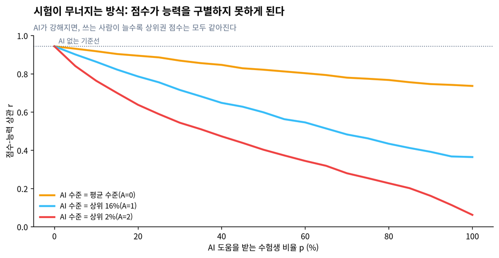

그림 4: 개념 시뮬레이션(예측 아님). 수험생 2만 명의 능력 θ~N(0,1)을 만들고, 비율 p의 수험생이 AI 도움을 받으면 점수를 max(θ, A)+오차로 두었다. A는 AI가 보장하는 수준이다. 세로축은 점수와 실제 능력의 상관(타당도 계수)이다. AI 수준이 높을수록, 그리고 사용 비율이 중간을 넘을수록 시험은 능력을 거의 구별하지 못한다. 수치는 모형 가정에 의존하며 실제 시험의 측정값이 아니다.

시뮬레이션의 핵심은 곡선의 모양이다. 처음에는 소수가 AI를 써서 오차가 조금 늘어나는 정도다. 그러다 AI 수준이 수험생 대부분보다 높아지고 사용 비율이 늘어나면, 점수 분포 위쪽이 **AI가 보장하는 점수 한 곳에 쌓인다.** 측정 도구가 천장에 닿은 것과 같은 상태다. 이때 시험은 능력을 재지 못한다. “AI를 썼는가”를 잴 뿐이다.

# 4 신호경제학의 시각: 자격증은 ‘비싸서’ 의미가 있었다

마이클 스펜스(Spence)의 신호 이론에 따르면 학위나 자격증의 가치는 거기 담긴 지식보다 **얻기 어렵다는 사실**에서 나온다. 능력이 높은 사람에게는 신호를 얻는 비용이 낮고 능력이 낮은 사람에게는 높다. 이 비용 차이가 있어야 신호가 사람들을 구별해 준다(분리 균형).

AI는 이 비용 차이를 없앤다. 문제를 찍어 보내는 비용은 능력과 관계없이 거의 같다. 신호를 얻는 비용이 평평해지면 시장은 **공동 균형(pooling)**으로 미끄러진다. 모두가 같은 신호를 갖게 되고, 신호는 정보를 잃는다.

세무사 사건이 무거운 이유가 여기 있다. 부정행위자 한 명이 합격한 것으로 끝나지 않는다. 그 시험의 **최근 3~5년치 합격자 전체의 신호 가치**가 의심받는다. 정부가 과거 시험까지 재점검하겠다고 나선 것은 행정 처리가 아니라 신호를 회수하는 작업이다. 신호경제학으로 보면, 부정행위 1건의 비용은 그 1건에 그치지 않는다. 같은 신호를 가진 모든 사람에게 나뉘어 떨어진다.

# 5 AI는 시험을 이미 졸업했다

반대쪽에서도 같은 일이 일어났다. 사람 시험이 AI 때문에 흔들리는 동안 **AI를 재는 시험**은 차례로 포화됐다. 2025년 1월 “인류의 마지막 시험(Humanity’s Last Exam, HLE)”이 나왔을 때 최고 모델의 정답률은 10% 안팎이었다. 출제진은 전문가도 풀기 어려운 문제만 골랐다고 했다. 공개 리더보드 기준으로 그 수치는 2026년 2월 약 37%, 같은 해 9~10월에는 60%를 넘었다.

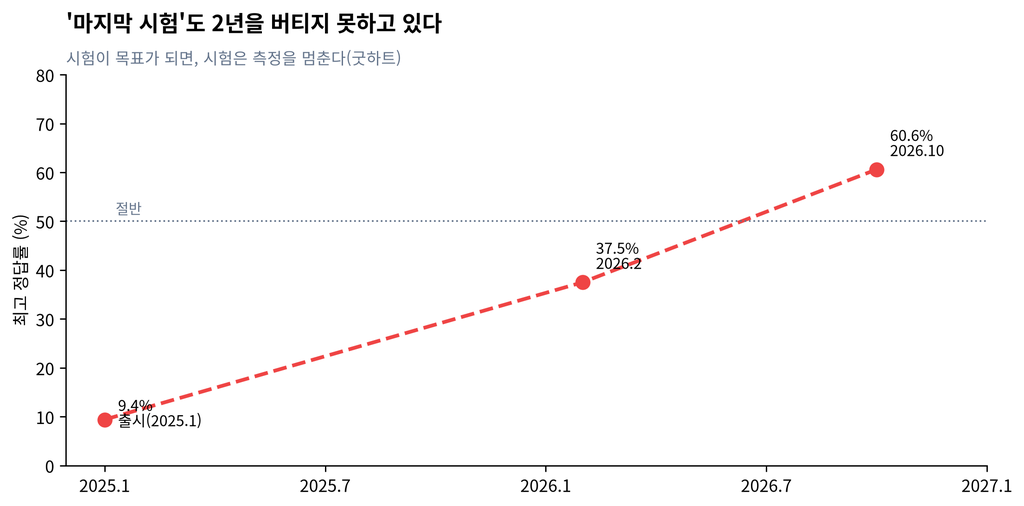

그림 5: Humanity’s Last Exam 최고 정답률 추이. 2025.1은 공개 논문의 출시 시점 값(o1 9.1%, DeepSeek-R1 9.4% 수준)이다. 2026.2(37.5%)와 2026.10(60.6%)은 Scale AI 리더보드 스냅샷을 인용한 집계 사이트 값이다. 도구 사용 여부와 집계처에 따라 수치가 다르며, 점선은 단순 보간이다. 출처: Phan et al. 2025, Scale AI HLE 리더보드(benchlm.ai 등 재인용).

한국 수능도 마찬가지다. 2025년 11월 연합뉴스와 연세대 연구팀이 2026학년도 수능 국어·수학·영어를 상용 AI에 풀게 했을 때 결과는 모델마다 크게 달랐다. 해외 추론형 모델은 상위권 점수를 받았지만 일부 국내 모델은 20점대였다. 이 차이도 빠르게 줄고 있다. 굿하트의 법칙(“측정이 목표가 되면 좋은 측정이 아니게 된다”)은 원래 사람의 행동을 두고 한 말이었다. 이제는 기계에도 그대로 적용된다. 모델은 시험을 목표로 학습되고, 시험은 측정 기능을 잃어 간다.

이 두 흐름은 하나로 이어진다. **AI가 시험을 잘 칠수록, 사람의 시험은 AI가 대신 칠 수 있는 대상이 된다.** AI 벤치마크의 포화와 사람 시험의 부정행위는 같은 능력이 두 방향으로 드러난 것이다.

# 6 보안공학의 시각: 막는 쪽이 지는 비대칭

보안공학의 오래된 교훈이 있다. **공격자는 한 곳만 뚫으면 되고 방어자는 모든 곳을 막아야 한다.** 시험 감독도 똑같은 구조가 됐다.

- **탐지는 신뢰를 잃고 있다.** 일부 대학은 2026~2027학년도부터 턴잇인의 AI 작성 탐지 기능을 평가에 쓰지 않기로 했다. 오탐이 문제였다. HEPI 2026 조사에서는 학생들이 “억울하게 부정행위자로 몰릴까 봐” 걱정하는 응답이 눈에 띄었다.
- **물리적 감독은 기기 소형화를 따라가지 못한다.** 중앙대 의대는 2025년 9월 “안경다리가 비정상적으로 두꺼운지 보라”는 지침을 만들었다. 1년 뒤 그 지침은 거의 쓸모가 없어졌다. 다리가 얇고 디스플레이가 없는 음성형 기기가 나왔기 때문이다.
- **방어 비용은 누적된다.** 전파탐지기, CCTV, 안경 전수조사, 녹화, 제보센터는 시험마다, 고사실마다, 해마다 들어가는 비용이다. 공격 쪽은 기기 하나를 한 번 사면 된다.

경계에서 나오는 결론은 이렇다. 계량심리학은 “조건이 지켜져야 점수가 의미 있다”고 말한다. 보안공학은 “그 조건을 지키는 비용은 계속 오른다”고 말한다. 신호경제학은 “조건이 뚫리면 같은 신호를 가진 모든 사람이 손해를 본다”고 말한다. 세 가지를 합치면 이렇게 된다. **조건을 지키는 비용이 그 시험이 주는 신호의 가치를 넘는 순간, 그 시험은 경제적으로 끝난다.** 대규모 비대면 시험과 결과물만 보는 과제가 먼저 그 선을 넘었다.

# 7 무엇이 살아남는가: 산출물에서 과정으로, 과정에서 대화로

결과물만으로 평가할 수 없게 되자 평가가 옮겨 가는 곳이 보인다.

1. **대화(구술)**: AP 보도(2026.4)에 따르면 코넬·펜실베이니아대·NYU 교수들이 구술시험을 되살리고 있다. 구술시험이 사라진 이유는 비용이었다. 그런데 AI가 그 비용을 낮추고 있다. NYU의 파노스 이페이로티스는 AI가 진행하는 구술시험으로 9일 동안 학생 36명을 평가했다. 사람이 진행하는 것보다 훨씬 쌌다. 크로니클 보도(2026.9)에 따르면 MIT 관련 공학 강좌 10개에서 15분 안팎의 짧은 구술시험 8,500회를 주로 화상으로 치렀다.
2. **과정 기록**: 풀이 과정, 초안 이력, 연구 노트를 같이 내게 하는 방식이다. 점수를 매기는 대상이 답에서 **답에 이르는 궤적**으로 바뀐다.
3. **AI 사용을 전제한 평가와 AI 없는 평가의 분리**: HEPI는 AI 사용을 기대하는 과제와 AI 없이 치르는 평가를 나란히 두라고 권고했다. 둘 중 하나를 고르라는 말이 아니라, **무엇을 재는지 따로 밝히라**는 말이다.

여기서 역설이 나온다. AI 때문에 끝난 시험 형식이 AI 덕분에 다시 가능해지고 있다. 구술시험은 “시간이 너무 든다”는 이유로 대량 필기시험에 밀려났는데, AI가 그 비용 문제를 풀어 주면서 돌아오고 있다. 시험의 종말은 **대량 필기시험이 표준이던 시대가 끝나는 것**이지, 평가가 끝나는 것이 아니다.

# 8 반대해석

**경고이 논증이 틀릴 수 있는 지점**

- **적발 증가는 탐지 증가일 수 있다.** 영국의 1,000명당 1.6건 → 5.1건은 부정행위가 늘었다는 뜻일 수도 있지만, 대학들이 AI 부정행위를 따로 세기 시작했다는 뜻일 수도 있다. 응답 기관의 27% 이상이 별도 분류를 하지 않았으니 둘 다 측정 오차가 크다.
- **AI 사용은 부정행위가 아니다.** HEPI의 94%는 대부분 개념 설명·요약·구조화에 쓴 것이다. 이 수치를 “94%가 커닝한다”로 읽으면 안 된다. 이 글의 주장은 “결과물만으로는 구별이 안 된다”까지다.
- **고부담 대면 시험은 아직 대체로 작동한다.** 수능·국가자격 시험에서 보도된 적발은 수십만 명 가운데 몇 건이다. “시험이 끝났다”는 말은 비대면·과제형 평가에 대해서는 맞지만, 철저히 감독되는 대면 시험에 대해서는 과장이다. 다만 적발되지 않은 사례가 얼마나 되는지는 정의상 알 수 없다.
- **구술시험도 완벽하지 않다.** AI로 그럴듯한 답을 연습해 외우고 들어올 수 있다. 직접 공부한 학생이 긴장해서 말을 못 할 수도 있다. 교수 시간과 인프라가 많이 드는 탓에 재정이 넉넉한 대학과 그렇지 못한 대학의 격차가 커질 수 있다. 서던퀸즐랜드대 연구는 구술시험을 필기·실기와 함께 쓸 때 가장 유용하다고 본다.
- **시험의 다른 기능은 남는다.** 시험에는 측정 말고도 학습 효과가 있다. 기억해 내는 과정 자체가 학습을 강화한다(인출 연습 효과, Roediger & Karpicke 2006). 측정 도구로서의 시험이 흔들려도 학습 도구로서의 시험은 AI와 상관없이 유효하다.
- **시뮬레이션은 예측이 아니다.** 그림의 타당도 곡선은 “AI가 능력의 하한을 보장한다”는 단순한 가정에 기댄다. 실제 AI 도움은 문항마다 효과가 다르고, 들킬 위험이 행동을 바꾼다.

# 9 결론: 시험은 ’조건’을 다시 설계해야 한다

AI 시대의 평가는 두 질문을 따로 물어야 한다. **이 사람은 혼자서 무엇을 할 수 있는가**, 그리고 **이 사람은 AI와 함께 무엇을 할 수 있는가.** 지금까지의 시험은 첫 번째 질문만 물었고 그 조건을 싸게 지킬 수 있었다. 이제 그 조건은 비싸다. 그래서 첫 번째 질문은 적게, 비싸게, 대면으로 묻게 된다. 두 번째 질문은 많이, 과정을 기록하면서 묻게 된다.

수능 전날 세무사 수석이 자백한 것은 우연이지만 상징적이다. 한 사회가 사람을 줄 세우던 가장 싼 방법이 끝나 가고 있다. 그 자리에는 더 비싸고, 더 느리고, 더 사람을 마주 보는 평가가 들어올 것이다. **시험은 끝나지 않는다. 싼 시험이 끝날 뿐이다.**

# 10 참고 문헌

- MTN, “산업인력공단 ‘세무사 수석합격자 고발…국가자격시험 전수조사’”, 2026.11.15; “정부 ‘3~5년치 세무사 시험 재점검’”, 2026.11.16.
- 서울신문, “수시 논술시험장서 ‘AI 안경’ 또 적발… 수능 감독 체계 ‘경고등’”, 2026.10.14.
- 연합뉴스, “안경다리 만지는지 관찰하라?…‘AI커닝’ 진화에 대학가 속수무책”, 2026.8.2.
- 경향신문·서울신문, 연세대·고려대 중간고사 집단 부정행위 보도, 2025.11.10.
- The Guardian, “Revealed: Thousands of UK university students caught cheating using AI”, 2025.6 (eWeek 재인용).
- HEPI & Kortext, *Student Generative AI Survey 2026* (HEPI Report 199), 2026.3; 2024·2025년 판.
- AP, “Perfect homework, blank stares: Why colleges are turning to oral exams to combat AI”, 2026.4.
- The Chronicle of Higher Education, “The Return of the Oral Exam”, 2026.9.
- University of Southern Queensland / The Conversation, 구술시험과 AI 부정행위, 2026.8.
- Phan, L. et al., “Humanity’s Last Exam”, arXiv:2501.14249, 2025; Scale AI HLE 리더보드.
- 연합뉴스 팩트체크, “AI가 수능 문제 풀어보니”, 2025.11.15.
- Messick, S., “Validity”, in *Educational Measurement* (3rd ed.), 1989.
- Spence, M., “Job Market Signaling”, *Quarterly Journal of Economics* 87(3), 1973.
- Goodhart, C., “Problems of Monetary Management: The U.K. Experience”, 1975.
- Roediger, H. L. & Karpicke, J. D., “Test-Enhanced Learning”, *Psychological Science* 17(3), 2006.